# More metadata - how preprints and publications are linked in Crossref

Bianca Kramer

March 9, 2020

## Linking preprints and published articles

Preprints allow rapid dissemination of research results, early feedback, and potential diversification of how peer review is organized. As such, preprints can be considered part of the ‘record of versions’ of a publication, that can also include a peer-reviewed version in a journal or other publication venue.

To be able to access this full ‘record of versions’, it is important to be able to link preprints to subsequent versions of the work. Such links can be displayed together with the preprint (Fig 1), which is useful for people who acccess the preprint that way. When these links are also included in the metadata of the preprint (and the published paper), they can be accessed programmatically and (re)used in various ways, e.g. for analysis, to combine citations to the preprint and published version, and to link both versions in discovery systems.

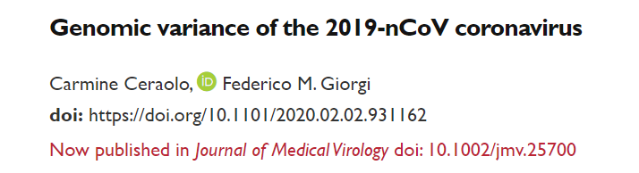

Fig 1 bioRxiv preprint with link to published paper

For preprint servers that use [Crossref](https://crossref.org) DOIs, Crossref notifies the preprint server of potential matches with published articles. It requires preprint servers to verify the links and add them to the metadata record of the preprint. (see [Crossref metadata: Posted content (includes preprints)](https://support.crossref.org/hc/en-us/articles/213126346-Posted-content-includes-preprints#assoc)). Crossref also recommends, but does not require, publishers to add links to preprints in the metadata of their publications.

So how many preprints actually have links to the published version in their metadata? And vice versa? Are there preprint servers (and publishers) that are particularly good in adding these links?

To investigate this, I queried the Crossref API for all records that include the field **is-preprint-of**, as well as all records that have the field **has-preprint**:

```
https://api.crossref.org/works?filter=relation.type:is-preprint-of
https://api.crossref.org/works?filter=relation.type:has-preprint
```

For each record, I collected information about the DOI, publisher, type, date created*, the DOI of the related preprint or published version, and whom the relation between preprint-published version was asserted by.

All code and data are available from this GitHub repo: crossref_preprints_publications.

## How many links?

On February 25 2020, there were **80,769** records in Crossref that *were* a preprint of another record, and **70,583** records that *had* a preprint version in Crossref. Of these records, **68,622** had reciprocal links, meaning that the relation was part of the metadata of both the preprint and the published version.

After retrieving metadata for the records that were only mentioned as being a preprint to a published article or vice versa, but did not themselve mention the relation, **80,914** matches were made with complete metadata for both preprint and published article (Fig. 2).

A small number of DOIs mentioned as preprint (**158**) or as having a preprint (**1658**) could not be retrieved from Crossref. This was mostly due to DOIs not resolving or not being Crossref DOIs (e.g. DataCite DOIs for Zenodo, ResearchGate or OSF (files and projects outside preprint servers)).

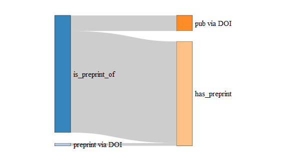

Fig 2 Flow diagram: links between preprints (blue) and published versions (orange) in Crossref (80,914 matches)

## Which preprint archives? Which publishers?